# Brand Competition Map using PCA

Neon(Youfang) Zhang

3/16/2022

```r
library(glmnet)
library(readxl)

# Importing the data and assigning x and y
cars_data <-  read_excel("Cars_Data.xlsx", sheet = "Infinity Data")
head(cars_data)
```

```
## # A tibble: 6 × 17
##   Brands   Attractive Quiet Unreliable `Poorly Built` Interesting Sporty
##   <chr>         <dbl> <dbl>      <dbl>          <dbl>       <dbl>  <dbl>
## 1 Infinity        5.6   6.3        2.9            1.6         3.6    4.1
## 2 Ford            4     3.6        4.2            4.2         5      4.9
## 3 Audi            4.6   5.2        3.7            2.6         4      3.8
## 4 Toyota          5.6   4.2        2              2.1         4.3    6.2
## 5 Eagle           4     3.5        4.3            4.3         3.9    4.9
## 6 Honda           5.2   5.4        3.2            2.8         3.4    5.1
## # … with 10 more variables: Uncomfortable <dbl>, Roomy <dbl>,
## #   Easy Service <dbl>, Prestige <dbl>, Common <dbl>, Economical <dbl>,
## #   Successful <dbl>, AvantGarde <dbl>, Poor Value <dbl>,
## #   Overall Preference <dbl>
```

Prepare for the PCA

```r
y <-  cars_data[,17]
x <-  as.matrix(cars_data[,2:16])

# Creating the correlation matrix
cor_mat = cor(x)
```

# Principal Components Analysis

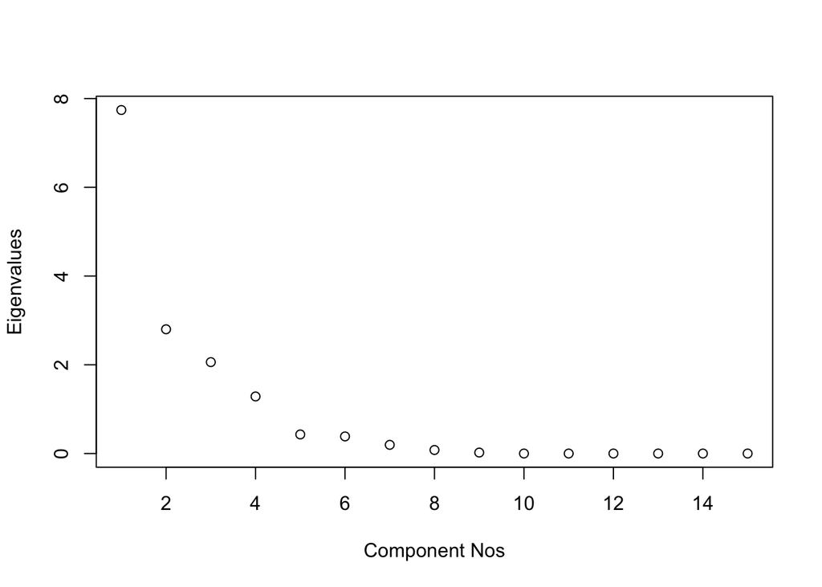

```r
out1 <-  eigen(cor_mat) # eigen decomposition of correlation matrix
va <-  out1$values          # eigenvalues
ve <-  out1$vectors     # eigenvector

# Scree Plot
plot(va, ylab = "Eigenvalues", xlab = "Component Nos")
```

Retain the factors whose eigenvalue > 1. In this way, we remain 4 factors to build our model.

The components of these 4 factors are shown as follows:

```r
ego <- va[va > 1]                           # eigenvalues > 1
nn <- nrow(as.matrix(ego))      # number of factors to retain
print(nn)
```

```
## [1] 4
```

```r
out2 <- ve[,1:nn]                           # eigenvectors associated with the retained factors
out3 <- ifelse(abs(out2) < 0.3, 0, out2)        # ignore small values < 0.3

rownames(out3) <- c("Attractive",   "Quiet",    "Unreliable",   "Poorly Built", "Interesting",  "Sporty",   "Uncomfortable",    "Roomy",    "Easy Service", "Prestige", "Common",   "Economical",   "Successful",   "AvantGarde",   "Poor Value")

out3
```

```
##                     [,1]       [,2]       [,3]       [,4]
## Attractive    -0.3262814  0.0000000  0.0000000  0.0000000
## Quiet         -0.3173818  0.0000000  0.0000000  0.0000000
## Unreliable     0.0000000 -0.4011014  0.0000000  0.0000000
## Poorly Built   0.3319244  0.0000000  0.0000000  0.0000000
## Interesting    0.0000000  0.0000000 -0.4290683  0.0000000
## Sporty         0.0000000  0.4288285  0.0000000  0.0000000
## Uncomfortable  0.0000000  0.0000000  0.0000000  0.0000000
## Roomy          0.0000000 -0.3789204  0.0000000  0.0000000
## Easy Service   0.0000000  0.4279673  0.0000000  0.0000000
## Prestige      -0.3322855  0.0000000  0.0000000  0.0000000
## Common         0.0000000  0.0000000  0.0000000 -0.4663407
## Economical     0.0000000  0.0000000  0.6642165  0.0000000
## Successful    -0.3155394  0.0000000  0.0000000  0.0000000
## AvantGarde     0.0000000  0.0000000  0.0000000  0.6685725
## Poor Value     0.0000000  0.0000000 -0.4710589  0.0000000
```

Now we can use these 4 factors to run our model.

```r
z_test <- x %*% out3
out_test <- lm(as.matrix(y) ~ z_test)
summary(out_test)
```

```
##
## Call:
## lm(formula = as.matrix(y) ~ z_test)
##
## Residuals:
##        1        2        3        4        5        6        7        8
## -0.41399  0.20488  0.21196  0.17883 -0.17872  0.29476  0.07001 -0.13008
##        9       10
## -0.11977 -0.11788
##
## Coefficients:
##             Estimate Std. Error t value Pr(>|t|)
## (Intercept)  2.18458    0.43161   5.061 0.003895 **
## z_test1     -0.68944    0.07258  -9.499 0.000219 ***
## z_test2     -0.28516    0.11920  -2.392 0.062209 .
## z_test3      0.46138    0.11900   3.877 0.011675 *
## z_test4      0.21219    0.21267   0.998 0.364205
## ---
## Signif. codes:  0 '***' 0.001 '**' 0.01 '*' 0.05 '.' 0.1 ' ' 1
##
## Residual standard error: 0.303 on 5 degrees of freedom
## Multiple R-squared:  0.9742, Adjusted R-squared:  0.9536
## F-statistic: 47.21 on 4 and 5 DF,  p-value: 0.0003671
```

Because Z1 and Z2 are negative, to make sure the slope of the later ideal vector arrow is positive, we change the signs of those two vectors.

```r
out4 <- out3
out4[,1] <- -1*out3[,1]
out4[,2] <- -1*out3[,2]

out4
```

```
##                     [,1]       [,2]       [,3]       [,4]
## Attractive     0.3262814  0.0000000  0.0000000  0.0000000
## Quiet          0.3173818  0.0000000  0.0000000  0.0000000
## Unreliable     0.0000000  0.4011014  0.0000000  0.0000000
## Poorly Built  -0.3319244  0.0000000  0.0000000  0.0000000
## Interesting    0.0000000  0.0000000 -0.4290683  0.0000000
## Sporty         0.0000000 -0.4288285  0.0000000  0.0000000
## Uncomfortable  0.0000000  0.0000000  0.0000000  0.0000000
## Roomy          0.0000000  0.3789204  0.0000000  0.0000000
## Easy Service   0.0000000 -0.4279673  0.0000000  0.0000000
## Prestige       0.3322855  0.0000000  0.0000000  0.0000000
## Common         0.0000000  0.0000000  0.0000000 -0.4663407
## Economical     0.0000000  0.0000000  0.6642165  0.0000000
## Successful     0.3155394  0.0000000  0.0000000  0.0000000
## AvantGarde     0.0000000  0.0000000  0.0000000  0.6685725
## Poor Value     0.0000000  0.0000000 -0.4710589  0.0000000
```

Re-run the model again using modified factors.

```r
z = x %*% out4          # Component Scores; coordinates of the brands in the map
out5 = lm(as.matrix(y) ~ z)     # Preference Regression to estimate how benefits drive overall preferences = f(benefits)
summary(out5)
```

```
##
## Call:
## lm(formula = as.matrix(y) ~ z)
##
## Residuals:
##        1        2        3        4        5        6        7        8
## -0.41399  0.20488  0.21196  0.17883 -0.17872  0.29476  0.07001 -0.13008
##        9       10
## -0.11977 -0.11788
##
## Coefficients:
##             Estimate Std. Error t value Pr(>|t|)
## (Intercept)  2.18458    0.43161   5.061 0.003895 **
## z1           0.68944    0.07258   9.499 0.000219 ***
## z2           0.28516    0.11920   2.392 0.062209 .
## z3           0.46138    0.11900   3.877 0.011675 *
## z4           0.21219    0.21267   0.998 0.364205
## ---
## Signif. codes:  0 '***' 0.001 '**' 0.01 '*' 0.05 '.' 0.1 ' ' 1
##
## Residual standard error: 0.303 on 5 degrees of freedom
## Multiple R-squared:  0.9742, Adjusted R-squared:  0.9536
## F-statistic: 47.21 on 4 and 5 DF,  p-value: 0.0003671
```

# Brand Map in Z1 & Z3 space

Seeing from the components of Z1 & Z3, we can name the Z1 as ‘Popular & Good Engineering’, Z3 as ‘Basic & Affordable’.

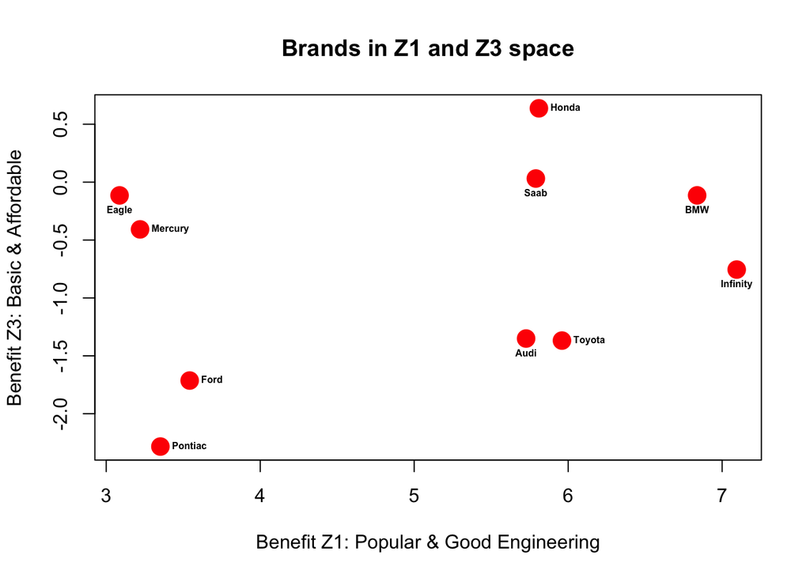

```r
# Coordinates of brands in (Z1, Z3) space
Z1 = z[,1]
Z3 = z[,3]
z.out = cbind(Z1, Z3)
rownames(z.out) = c("Infinity","Ford","Audi","Toyota","Eagle","Honda","Saab","Pontiac","BMW","Mercury")

# Plot the brand map
plot(Z1, Z3, main = "Brands in Z1 and Z3 space", xlab = "Benefit Z1: Popular & Good Engineering", ylab = "Benefit Z3: Basic & Affordable", col = "red", pch = 19, cex = 2)
text(z.out, labels = row.names(z.out), font = 2, cex = 0.5, pos = c(1,4))
```

Slopes and angles of iso-preference and ideal vector

The iso preference’s slope is -1.49, the car brand on the one line has the same preference score of customers.

And the direction of ideal vector is way car company to make improvement on customer popularity.

```r
# Slopes of iso-preference and ideal vector
b1 = as.vector(coef(out5)[2])
b2 = as.vector(coef(out5)[4])
slope.iso.preference = - b1/b2
slope.iso.preference
```

```
## [1] -1.494305
```

```r
slope.ideal.vector = b2/b1
slope.ideal.vector
```

```
## [1] 0.6692073
```

```r
# Angles of iso-preference and ideal vector
angle.iso.preference = atan(slope.iso.preference)*180/pi
angle.ideal.vector = atan(slope.ideal.vector)*180/pi
```

# Bootstrap

To get the 95% confidence interval for the angle of the ideal vector, we use bootstrap to extract data with replacement.

```r
set.seed(50)

colnames(z) <- c("Z1", "Z2", "Z3", "Z4")
data <- cbind(y, z)
bb <- 1000
nn <- nrow(data)

angle_ideal_vector_star <- rep(0,bb)

for (i in 1:bb) {
  data_star <- data[sample(nn, nn, replace=T),]
  y_star <- data_star[,1]
  z_star <- data_star[,2:ncol(data_star)]
  model <- lm(as.matrix(y_star) ~ as.matrix(z_star))
  model_coef <- coef(model)
  slope_ideal_vector_star <- model_coef[4]/model_coef[2]
  angle_ideal_vector_star[i] <- atan(slope_ideal_vector_star)*180/pi
}

conf_int <- quantile(angle_ideal_vector_star, c(0.025, 0.975), na.rm = TRUE)
round(conf_int,2)
```

```
##  2.5% 97.5%
## -4.65 61.07
```

The result of the 95% confidence interval for the angle of the ideal vector is (-4.65, 61.07), which means most of the measures to improve customer popularity will result in the improvement direction falling into this range.